# Analysis of the NOAA Storm Database and study the influence of the storm on health and economy

Dmitry

## Synopsis

Storms and other severe weather events can cause both public health and economic problems for communities and municipalities. Many severe events can result in fatalities, injuries, and property damage, and preventing such outcomes to the extent possible is a key concern. In this document storms and other severe weather events from the U.S. National Oceanic and Atmospheric Administration’s (NOAA) storm database are analyzed. Using whole data from 1950 to November 2011 questions about severe weather events were studied. The most harmful type of events with respect to population health and type of events with the greatest economic consequences were determined.

## Data Processing

For study was used this version of database file: https://d396qusza40orc.cloudfront.net/repdata%2Fdata%2FStormData.csv.bz2 and description: https://d396qusza40orc.cloudfront.net/repdata%2Fpeer2_doc%2Fpd01016005curr.pdf

### Getting data

At the first, the datafile was downloaded and read.

```r
DataUrl <-  "https://d396qusza40orc.cloudfront.net/repdata%2Fdata%2FStormData.csv.bz2"
fileName <- paste0(getwd(), "/../StormData.csv.bz2")
if(!file.exists(fileName)){
    download.file(DataUrl, fileName)
    }
NOAA_data <- read.csv(bzfile(fileName))
```

### Structure of data

There are several first lines of data presented to see structure of the data

```r
head(NOAA_data)
```

```
##   STATE__           BGN_DATE BGN_TIME TIME_ZONE COUNTY COUNTYNAME STATE
## 1       1  4/18/1950 0:00:00     0130       CST     97     MOBILE    AL
## 2       1  4/18/1950 0:00:00     0145       CST      3    BALDWIN    AL
## 3       1  2/20/1951 0:00:00     1600       CST     57    FAYETTE    AL
## 4       1   6/8/1951 0:00:00     0900       CST     89    MADISON    AL
## 5       1 11/15/1951 0:00:00     1500       CST     43    CULLMAN    AL
## 6       1 11/15/1951 0:00:00     2000       CST     77 LAUDERDALE    AL
##    EVTYPE BGN_RANGE BGN_AZI BGN_LOCATI END_DATE END_TIME COUNTY_END
## 1 TORNADO         0                                               0
## 2 TORNADO         0                                               0
## 3 TORNADO         0                                               0
## 4 TORNADO         0                                               0
## 5 TORNADO         0                                               0
## 6 TORNADO         0                                               0
##   COUNTYENDN END_RANGE END_AZI END_LOCATI LENGTH WIDTH F MAG FATALITIES
```

[output cut: 20 more lines]

Our study should answer two queston:

- Across the United States, which types of events (as indicated in the `EVTYPE` variable) are most harmful with respect to population health?
- Across the United States, which types of events have the greatest economic consequences?

Therefore for this study will be useful next column: `EVTYPE` `FATALITIES` `INJURIES` `PROPDMG` `CROPDMG` `PROPDMGEXP` `CROPDMGEXP`

`PROPDMGEXP` `CROPDMGEXP` indicate, who damage could be calculated. There are severel types of data in these column.

```r
NOAA_data$PROPDMGEXP <- as.factor(NOAA_data$PROPDMGEXP)
NOAA_data$CROPDMGEXP <- as.factor(NOAA_data$CROPDMGEXP)

print(levels(NOAA_data$PROPDMGEXP))
```

```
##  [1] ""  "-" "?" "+" "0" "1" "2" "3" "4" "5" "6" "7" "8" "B" "h" "H" "K"
## [18] "m" "M"
```

```r
print(levels(NOAA_data$CROPDMGEXP))
```

```
## [1] ""  "?" "0" "2" "B" "k" "K" "m" "M"
```

```r
powIndicator <- levels(as.factor(c(levels(NOAA_data$PROPDMGEXP),
                                   levels(NOAA_data$CROPDMGEXP))))[-1:-4]
print(powIndicator)
```

```
##  [1] "0" "1" "2" "3" "4" "5" "6" "7" "8" "B" "h" "H" "k" "K" "m" "M"
```

Damage can be calculated as `Expense = A * 10^B`, where A is number from `CROPDMG`/`PROPDMG` field and B is exponential values from table. Numbers are simply B-value, `h/H` for hundreds,`k/K` for thousands, etc.

```r
library("xtable")
ConvTable<-data.frame(DMGEXP = powIndicator, B = c(0,1,2,3,4,5,6,7,8,9,2,2,3,3,6,6))
xt <- xtable(ConvTable)
print(xt, type="html",include.rownames=FALSE)
```

| DMGEXP | B |
| --- | --- |
| 0 | 0.00 |
| 1 | 1.00 |
| 2 | 2.00 |
| 3 | 3.00 |
| 4 | 4.00 |
| 5 | 5.00 |
| 6 | 6.00 |
| 7 | 7.00 |
| 8 | 8.00 |
| B | 9.00 |
| h | 2.00 |
| H | 2.00 |
| k | 3.00 |
| K | 3.00 |
| m | 6.00 |
| M | 6.00 |

For our purposes `PROPDMG` `CROPDMG` field were recalculated acording this table to compute the total losses.

```r
for (e in ConvTable$DMGEXP){
    NOAA_data$PROPDMG[NOAA_data$PROPDMGEXP == e] <-
        NOAA_data$PROPDMG[NOAA_data$PROPDMGEXP == e]* 10 ^ ConvTable$B[ConvTable$DMGEXP == e]

    NOAA_data$CROPDMG[NOAA_data$CROPDMGEXP == e] <-
        NOAA_data$CROPDMG[NOAA_data$CROPDMGEXP == e]* 10 ^ ConvTable$B[ConvTable$DMGEXP == e]
}
```

## Results

### Analysis of weather events with respect to population health

There are aggregated harmful weather events with respect to population health.

```r
inj.sum <- aggregate(INJURIES ~ EVTYPE, NOAA_data, sum)
fat.sum <- aggregate(FATALITIES ~ EVTYPE, NOAA_data, sum)
```

There are 5 worst types of weather events with respect to population health.

- INJURIES

```r
inj.ten <- head(inj.sum[order(-inj.sum$INJURIES), ], 5)
print(inj.ten)
```

```
##             EVTYPE INJURIES
## 834        TORNADO    91346
## 856      TSTM WIND     6957
## 170          FLOOD     6789
## 130 EXCESSIVE HEAT     6525
## 464      LIGHTNING     5230
```

- FATALITIES

```r
fat.ten <- head(fat.sum[order(-fat.sum$FATALITIES), ], 5)
print(fat.ten)
```

```
##             EVTYPE FATALITIES
## 834        TORNADO       5633
## 130 EXCESSIVE HEAT       1903
## 153    FLASH FLOOD        978
## 275           HEAT        937
## 464      LIGHTNING        816
```

So, the most harmful effect is **Tornado**. The most harmful effects in order to injuries and fatalities are plotted.

[figure not shown]

```r
par(mfrow=c(1,2), mar=c(8,3,4,2)+0.1)
barplot(inj.ten$INJURIES, main="Injuries", ylab="Numbers of injuries",
        las=3, names.arg = inj.ten$EVTYPE)

barplot(fat.ten$FATALITIES, main="Fatalities", ylab="Numbers of fatalities",
        las=2, names.arg = inj.ten$EVTYPE)
```

Finally, there is evaluation the percentage of injuries and fatalities from **Tornado**.

```r
h <- fat.ten$FATALITIES[1]/ sum(fat.sum$FATALITIES)
print(paste0("Percentage of fatalities from Tornado:", h * 10, " %"))
```

[output not shown]

```r
h <- inj.ten$INJURIES[1]/ sum(inj.sum$INJURIES)
print(paste0("Percentage of injuries from Tornado:", h * 10, " %"))
```

[output not shown]

### Analysis of weather events with respect to economic consequences

Losses data for each type of damage was aggregated.

```r
crop.sum <- aggregate(CROPDMG ~ EVTYPE, NOAA_data, sum)
prop.sum <- aggregate(PROPDMG ~ EVTYPE, NOAA_data, sum)
```

`PROPDMG` `CROPDMG` were summed, because they both mesured in US dollars. The names of most harmful events were extracted from each column (in variable `EventNames`)

```r
a <- head(crop.sum[order(-crop.sum$CROPDMG), ], 5)
b <- head(prop.sum[order(-prop.sum$PROPDMG), ], 5)
EventNames <- c(as.vector(a$EVTYPE), as.vector(b$EVTYPE))
crop.sum <- crop.sum[crop.sum$EVTYPE %in% EventNames, ]
prop.sum <- prop.sum[prop.sum$EVTYPE %in% EventNames, ]
p.sum <- merge(crop.sum, prop.sum, by="EVTYPE")
p.sum$SUM <- p.sum$CROPDMG + p.sum$PROPDMG
```

There are 5 worst types of weather events with respect to money losses.

```r
p.ten <- head(p.sum[order(-p.sum$SUM), ], 5)

row.names(p.ten) <- p.ten$EVTYPE
print(p.ten[,c(1,4)], row.names = FALSE)
```

```
##             EVTYPE          SUM
##              FLOOD 150319678257
##  HURRICANE/TYPHOON  71913712800
##            TORNADO  57362333947
##        STORM SURGE  43323541000
##               HAIL  18761221986
```

So, the most harmful effect is **Flood**. The most harmful effects in order to money loss are plotted.

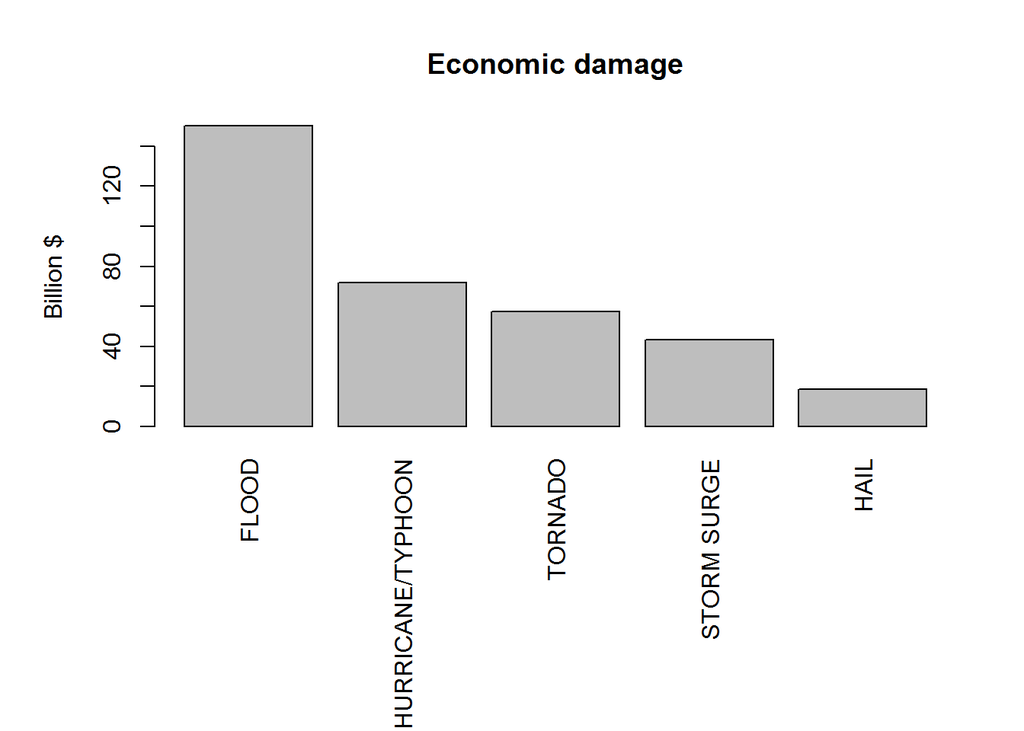

```r
par(mar=c(10,5,4,2)+0.3)
barplot(p.ten$SUM/ 1e9, main="Economic damage", ylab="Billion $",
        las=3, names.arg = p.ten$EVTYPE)
```

Finally, there is evaluation the percentage of money loss from **Flood**.

```r
h <- p.ten$SUM[1]/ (sum(crop.sum$CROPDMG) + sum(prop.sum$PROPDMG))
print(paste0("Percentage of money loss from Tornado:", h * 10, " %"))
```

[output not shown]